# Team#11_MidTermProject

## **Introduction**

#### **Title**:

Global University Rankings Analysis (2020–2025): Understanding Trends in Higher Education

#### **Names**:

- **Sakina Saifuddin - 2512137 (Team Manager)**
- Sandra Ann Thomas - 2457188
- Bathini Shanmukha priya - 2490778
- Sanju Shree Chandrasekaran - 2447501
- Satish korada - 2400066

#### **Context**:

This dataset contains information about global university rankings published by the Center for World University Rankings (CWUR) from 2020 to 2025. It includes details such as each university’s world rank, national rank, education rank, employability rank, faculty rank, research rank, and overall score.

The data reflects the performance of universities from different countries based on education quality, research strength, and graduate employability.

#### **Problem Statement**:

The CWUR ranks universities worldwide based on education, research, and employability.Since the data is spread across different years, it’s hard to see changes and trends.This project collects and analyzes CWUR data from 2020–2025 & it aims to find trends, identify top-performing countries and universities, and understand which factors influence ranking performance.

#### **Objectives:**:

The main objectives of this project are to:

- Collect CWUR university ranking data from 2020 to 2025 using web scraping.
- Combine data from all years into one clean and structured dataset.
- Analyze and compare the rankings of universities and countries over time.
- Identify the top-performing universities and countries each year.
- Explore how different factors (education, employability, faculty, research) affect overall rankings.
- Visualize trends and patterns in global higher education.
- Generate insights that highlight changes in university performance worldwide.

## **Import Libraries**

```python
import pandas as pd
import matplotlib.pyplot as plt
import seaborn as sns
import numpy as np
import re
from sklearn.ensemble import RandomForestClassifier
from sklearn.model_selection import train_test_split
```

```python
!pip install requests-html lxml_html_clean
from requests_html import AsyncHTMLSession
import asyncio
import nest_asyncio
nest_asyncio.apply()
```

[output not shown]

#### **Observation**:

This code installs necessary libraries for asynchronous web scraping (requests-html and lxml_html_clean), imports them, and then uses nest_asyncio. apply() to enable asynchronous operations within the Colab environment.

## **Data Scraping**

```python
async def fetch_cwur(year):
    # Dynamically construct the URL based on the year
    if year >= 2023: # For 2023, 2024, 2025 and onwards
        url = f"https://cwur.org/{year}.php"
    else: # For 2020, 2021, 2022 use YYYY-YY.php format
        # Example: 2020 becomes 2020-21
        end_year_suffix = str(year + 1)[-2:]
        url = f"https://cwur.org/{year}-{end_year_suffix}.php"

    session = AsyncHTMLSession()
    r = await session.get(url)
    await r.html.arender(sleep=2, timeout=30)  # async rendering

    # Find the table
    table = r.html.find('table#cwurTable', first=True)

    all_rows_for_year = []

    # Define the header row (needed by scrape_all_years logic)
    header_row = [
        "World Rank",
        "University",
        "Country",
        "National Rank",
        "Education Rank",
        "Employability Rank",
        "Faculty Rank",
        "Research Rank",
        "Score",
        "Year"
    ]

    # If table is not found, print a warning and return an empty list of data rows.
    if not table:
        print(f"⚠️ Warning: Table 'cwurTable' not found for year {year} at {url}. Returning no data for this year.")
        # Return an empty list of data rows, the caller will handle the header separately.
        return [header_row] # Returning just header to maintain consistency for `scrape_all_years`

    # Iterate through table rows and extract data
    # Skip the first `tr` as it's typically the header in the HTML table.
    for row in table.find('tr')[1:]:
        cols = [c.text for c in row.find('td')]
        if cols:
            cols.append(str(year)) # Add the year as a string
            all_rows_for_year.append(cols)

    # Prepend the header row only if this fetch_cwur call is the one that's expected to provide the header.
    # However, the `scrape_all_years` function already handles adding the header once.
    # So, we just return the data rows, and `scrape_all_years` will manage the header from the first successful year's fetch.
    # To fit the current `scrape_all_years` logic (which expects data[0] to be header for first_year, and then data[1:] for subsequent), we always include the header here.
    all_rows_for_year.insert(0, header_row) # Insert header at the beginning

    return all_rows_for_year
```

#### **Observation**:

This fetch_cwur function scrapes university ranking data for a given year from the CWUR website. It builds the correct URL, loads the web page (including dynamic content), finds the ranking table, extracts all the data rows, adds the specified year to each row, and then returns the data along with a predefined header.

```python
all_years_data = []
years_to_scrape = range(2020, 2026) # Years from 2020 to 2025

async def scrape_all_years():
    global all_years_data # Declare all_years_data as global to modify it
    first_year = True

    for year in years_to_scrape:
        print(f"Scraping data for year: {year}")
        data = await fetch_cwur(year)

        if first_year:
            all_years_data.extend(data) # Include header for the first year
            first_year = False
        else:
            all_years_data.extend(data[1:]) # Exclude header for subsequent years
        print(f"✅ Data for year {year} collected.")

    print("✅ All years data combined successfully.")
```

#### **Observation**:

1. This code initializes an empty list to store all data.
2. It defines the years to scrape (2020-2025) and then, in the scrape_all_years function, it loops through each year, calls fetch_cwur to get data, and combines all the results into a single list, ensuring headers are only included once.

```python
# Run the async function
asyncio.run(scrape_all_years())
```

```
Scraping data for year: 2020
```

[output not shown]

```
✅ Data for year 2020 collected.
Scraping data for year: 2021
✅ Data for year 2021 collected.
Scraping data for year: 2022
✅ Data for year 2022 collected.
Scraping data for year: 2023
✅ Data for year 2023 collected.
Scraping data for year: 2024
✅ Data for year 2024 collected.
Scraping data for year: 2025
✅ Data for year 2025 collected.
✅ All years data combined successfully.
```

#### **Observation**:

1. This code executes the scrape_all_years() function, which scrapes university ranking data for all specified years (2020-2025).
2. This saves the 12,000+ scraped rows from the website.

```python
# Display the first few rows of the combined data (for verification)
print("\nFirst 5 rows of combined data:")
for row in all_years_data[:5]:
    print(row)
```

```
First 5 rows of combined data:
['World Rank', 'University', 'Country', 'National Rank', 'Education Rank', 'Employability Rank', 'Faculty Rank', 'Research Rank', 'Score', 'Year']
['1', 'Harvard University', 'USA', '1', '3', '1', '1', '1', '100', '2020']
['2', 'Massachusetts Institute of Technology', 'USA', '2', '4', '11', '2', '7', '96.7', '2020']
['3', 'Stanford University', 'USA', '3', '10', '4', '3', '2', '95.2', '2020']
['4', 'University of Cambridge', 'United Kingdom', '1', '1', '21', '4', '11', '94.1', '2020']
```

#### **Observation**:

1. The data shows the top universities from the year 2020. Harvard University ranks 1st, followed by MIT, Stanford, and University of Cambridge.
2. The dataset looks correct and includes all main columns like rank, university, country, score, and year.

```python
df = pd.read_csv("cwur_rankings_2020_2025.csv")
```

## **Data Description**

- World Rank: The university’s global position.
- University: Name of the institution.
- Country: The country where the university is located.
- National Rank: University’s position within its own country.
- Education Rank: Based on education quality and achievements.
- Employability Rank: Based on alumni employment outcomes.
- Faculty Rank: Based on faculty achievements and awards.
- Research Rank: Based on research output and impact.
- Score: Overall CWUR score based on all factors.
- Year: The year of ranking data (2020–2025).

## **Loading (Reading) Dataset**

```python
cwur_copy=df.copy()
print("\nFirst 5 rows of the data copied to new variable:")
print(cwur_copy.head())
```

```
First 5 rows of the data copied to new variable:
  World Rank                             University         Country  \
0          1                     Harvard University             USA
1          2  Massachusetts Institute of Technology             USA
2          3                    Stanford University             USA
3          4                University of Cambridge  United Kingdom
4          5                   University of Oxford  United Kingdom

   National Rank Education Rank Employability Rank Faculty Rank Research Rank  \
0              1              3                  1            1             1
1              2              4                 11            2             7
2              3             10                  4            3             2
3              1              1                 21            4            11
4              2              7                 26            9             4

   Score  Year
0  100.0  2020
1   96.7  2020
2   95.2  2020
3   94.1  2020
4   93.3  2020
```

#### **Observation**:

This line of code displays the first five data rows of the data copied to new variable named cwur_copy, which copies the data using one of the pandas method i.e. .copy()

# **EDA:**

## A) Basic Data Exploration

**i. Checking data attributes (shape, size, dimensionality, data types, column names)**

```python
print("shape: ",cwur_copy.shape)
```

```
shape:  (12000, 10)
```

#### **Observation**

This gets the number of rows (12000) and columns(10)

```python
print("size:", cwur_copy.size) # size of the dataset
```

```
size: 120000
```

#### **Observation**

Total number of rows & columns i.e. the size of the dataset is 12000 x 10 = 120000 size

```python
print("dimension:", cwur_copy.ndim)
```

```
dimension: 2
```

#### **Observation**

```python
print("data types:", cwur_copy.dtypes)
```

```
data types: World Rank             object
University             object
Country                object
National Rank           int64
Education Rank         object
Employability Rank     object
Faculty Rank           object
Research Rank          object
Score                 float64
Year                    int64
dtype: object
```

#### **Observation:**

It gets the data types/dimensions of all the columns/attributes

```python
print("column names:", cwur_copy.columns)
```

```
column names: Index(['World Rank', 'University', 'Country', 'National Rank',
       'Education Rank', 'Employability Rank', 'Faculty Rank', 'Research Rank',
       'Score', 'Year'],
      dtype='object')
```

#### **Observation**

It gets all the column names

**ii. Getting data information**

```python
print("getting data info ", cwur_copy.info());
```

```
<class 'pandas.core.frame.DataFrame'>
RangeIndex: 12000 entries, 0 to 11999
Data columns (total 10 columns):
 #   Column              Non-Null Count  Dtype
---  ------              --------------  -----
 0   World Rank          12000 non-null  object
 1   University          12000 non-null  object
 2   Country             12000 non-null  object
 3   National Rank       12000 non-null  int64
 4   Education Rank      12000 non-null  object
 5   Employability Rank  12000 non-null  object
 6   Faculty Rank        11971 non-null  object
 7   Research Rank       12000 non-null  object
 8   Score               12000 non-null  float64
 9   Year                12000 non-null  int64
dtypes: float64(1), int64(2), object(7)
memory usage: 937.6+ KB
getting data info  None
```

#### **Observation:**

**iii. Examining the data statistical summary**

```python
print("To get the summary", cwur_copy.describe)
```

```
To get the summary <bound method NDFrame.describe of            World Rank                             University         Country  \
0                   1                     Harvard University             USA
1                   2  Massachusetts Institute of Technology             USA
2                   3                    Stanford University             USA
3                   4                University of Cambridge  United Kingdom
4                   5                   University of Oxford  United Kingdom
...               ...                                    ...             ...
11995  1996\nTop 9.4%         Hunan University of Technology           China
11996  1997\nTop 9.4%              Guizhou Normal University           China
11997  1998\nTop 9.4%              Bengbu Medical University           China
11998  1999\nTop 9.4%         Federal University of Amazonas          Brazil
11999  2000\nTop 9.4%                     Başkent University          Turkey

       National Rank Education Rank Employability Rank Faculty Rank  \
0                  1              3                  1            1
```

[output cut: 25 more lines]

**Observation:**

- The dataset has 12,000 rows and 10 columns.
- Data covers university rankings from 2020 to 2025.
- Columns include world rank, national rank, education rank, score, and more.
- Some columns have missing values shown as “-”.
- The dataset includes universities from many different countries.
- Shows a wide range of global university rankings and scores.

**iv. Getting a summary of the categorical variables**

```python
print("to get summary fo the categorical University Names", cwur_copy['University'].describe())
```

```
to get summary fo the categorical University Names count                                            12000
unique                                            2252
top       Chengdu University of Information Technology
freq                                                 6
Name: University, dtype: object
```

```python
print("to get summary fo the categorical Country Names:", cwur_copy['Country'].describe())
```

```
to get summary fo the categorical Country Names: count     12000
unique       99
top         USA
freq       2019
Name: Country, dtype: object
```

**Observation:**

1. The dataset contains 99 unique countries.
2. USA appears most frequently with 2,019 universities, making it the top country in the dataset.
3. There are 2,252 unique universities in total.
4. Chengdu University of Information Technology appears most often, with a frequency of 6.
5. This shows the dataset is diverse, with universities from many countries, but some countries and universities appear more frequently than others.

**v. Checking on missing values**

```python
print("Checking missing values where '-' indicates a missing value:\n", (cwur_copy == '-').sum())
```

```
Checking missing values where '-' indicates a missing value:
 World Rank                0
University                0
Country                   0
National Rank             0
Education Rank         9388
Employability Rank     5974
Faculty Rank          10342
Research Rank           401
Score                     0
Year                      0
dtype: int64
```

**Observation:**

- Some columns have missing data represented by "-".
- Education Rank has 9,388 missing values, Employability Rank has 5,974, and Faculty Rank has 10,342 missing.
- Research Rank has 401 missing values.
- Columns like World Rank, University, Country, Score, and Year have no missing values.
- This shows that while some ranking details are incomplete, the core information (university, country, score, year) is fully available.

**vi. Examining outliers**

```python
# Define columns that should be numeric for outlier analysis
numeric_cols_for_outliers = ['World Rank', 'National Rank', 'Education Rank', 'Employability Rank', 'Faculty Rank', 'Research Rank', 'Score']
```

```python
df_numeric = cwur_copy.copy()
# Replace '-' with NaN across the specified columns
for col in numeric_cols_for_outliers:
    df_numeric[col] = df_numeric[col].replace('-', np.nan)
```

```python
# Clean 'World Rank' and 'National Rank' by extracting only the numerical part
# Some values like '1996\nTop\xa09.4%' need to be handled
for col in ['World Rank', 'National Rank']:
    df_numeric[col] = df_numeric[col].astype(str).str.split('\n').str[0]
```

```python
# Convert to numeric, coercing errors will turn problematic values into NaN
for col in numeric_cols_for_outliers:
    df_numeric[col] = pd.to_numeric(df_numeric[col], errors='coerce')
```

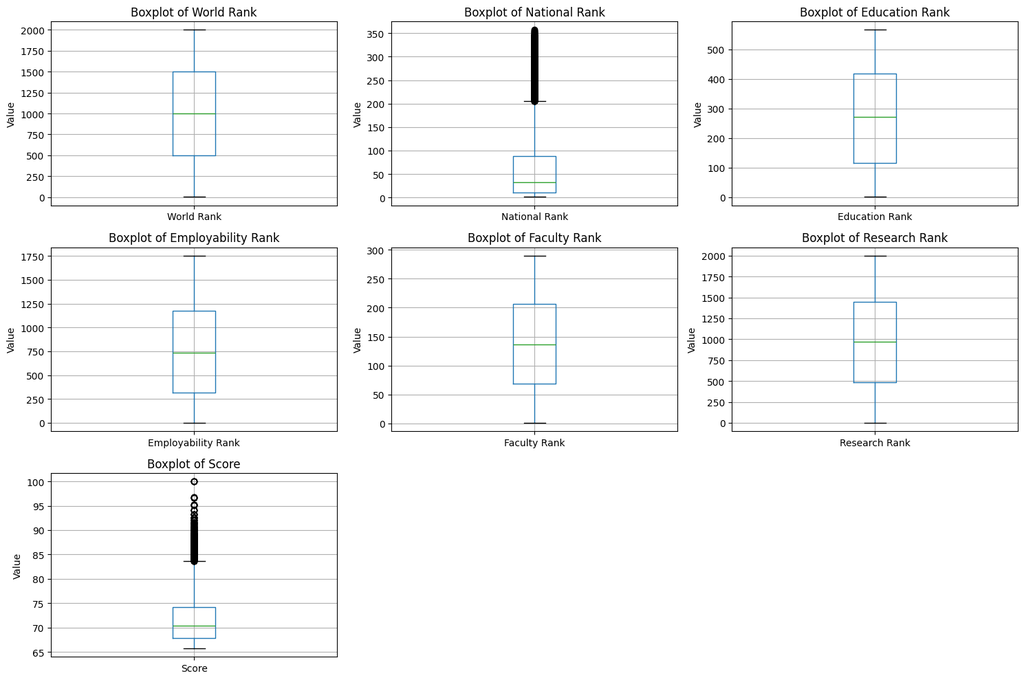

```python
# Drop rows with NaN values in these numeric columns if you want to analyze only complete data
# Alternatively, boxplot can handle NaNs by default, but it's good to be aware.
# For now, let's proceed with NaNs, as boxplot will ignore them.

# Boxplot for each numeric column to spot outliers
plt.figure(figsize=(15, 10))
for i, col in enumerate(numeric_cols_for_outliers):
    plt.subplot(3, 3, i + 1) # Adjust subplot grid as needed
    df_numeric.boxplot(column=col)
    plt.title(f'Boxplot of {col}')
    plt.ylabel('Value')
plt.tight_layout()
plt.show()
```

**Observation**

- World Rank – The ranks are spread widely from 0 to about 2000, showing a big difference between universities.
- National Rank – Most ranks are below 100, but there are many outliers (black dots) above 200, meaning a few universities are ranked much lower nationally.
- Education Rank – The data is spread out, but most universities have ranks between 100 and 400.
- Employability Rank – The spread is large, from 0 to 1750, showing strong differences in employability among universities.
- Faculty Rank – Most values fall between 50 and 250, meaning faculty ranks are more consistent compared to other categories.
- Research Rank – The spread is wide (0–2000), showing that research performance varies a lot among universities.
- Score – Most scores are between 65 and 75, but there are some high outliers above 90, meaning only a few universities have very high overall scores.

### B) Univariate, Bivariate, and Multivariate Analyses

#### 1. Replace '-' with NaN for consistency

```python
# Replace '-' with NaN for consistency
cwur_copy.replace('-', np.nan, inplace=True)
```

```python
cwur_copy.tail()
```

|  | World Rank | University | Country | National Rank | Education Rank | Employability Rank | Faculty Rank | Research Rank | Score | Year |
| --- | --- | --- | --- | --- | --- | --- | --- | --- | --- | --- |
| 11995 | 1996\nTop 9.4% | Hunan University of Technology | China | 344 | NaN | NaN | NaN | 1920 | 66.2 | 2025 |
| 11996 | 1997\nTop 9.4% | Guizhou Normal University | China | 345 | NaN | NaN | NaN | 1922 | 66.2 | 2025 |
| 11997 | 1998\nTop 9.4% | Bengbu Medical University | China | 346 | NaN | NaN | NaN | 1924 | 66.2 | 2025 |
| 11998 | 1999\nTop 9.4% | Federal University of Amazonas | Brazil | 53 | NaN | NaN | NaN | 1925 | 66.2 | 2025 |
| 11999 | 2000\nTop 9.4% | Başkent University | Turkey | 52 | NaN | 1223 | NaN | 1930 | 66.2 | 2025 |

**Observation:**

Placeholder symbols like '-' are replaced with NaN to ensure accurate numeric processing in the following steps.

#### 2. Clean and Convert Data Types

```python
# Clean 'World Rank' and 'National Rank' columns (remove text like '\nTop 9.4%')
cwur_copy['World Rank'] = cwur_copy['World Rank'].astype(str).str.split('\n').str[0]
cwur_copy['National Rank'] = cwur_copy['National Rank'].astype(str).str.split('\n').str[0]
```

```python
# Convert numeric columns from object → float
numeric_cols = ['World Rank', 'National Rank', 'Education Rank',
                'Employability Rank', 'Faculty Rank', 'Research Rank', 'Score']

for col in numeric_cols:
    cwur_copy[col] = pd.to_numeric(cwur_copy[col], errors='coerce')
```

```python
cwur_copy.dtypes
```

```
World Rank              int64
University             object
Country                object
National Rank           int64
Education Rank        float64
Employability Rank    float64
Faculty Rank          float64
Research Rank         float64
Score                 float64
Year                    int64
dtype: object
```

**Observation:**

• Removed textual parts (like “Top %”) from World Rank and National Rank. • Converted columns such as World Rank, National Rank, Education Rank, Employability Rank, Faculty Rank, Research Rank, and Score from object to numeric (float64) type.

#### 3. Handle Missing Values

```python
# Fill missing ranking columns with median (less biased than mean)
rank_cols = ['Education Rank', 'Employability Rank', 'Faculty Rank', 'Research Rank']

for col in rank_cols:
    cwur_copy[col].fillna(cwur_copy[col].median(), inplace=True)
```

```python
cwur_copy.isna().sum()
```

```
World Rank            0
University            0
Country               0
National Rank         0
Education Rank        0
Employability Rank    0
Faculty Rank          0
Research Rank         0
Score                 0
Year                  0
dtype: int64
```

**Observation:**

• Missing values were found mainly in ranking columns like Education Rank, Employability Rank, Faculty Rank, and Research Rank.

• These were replaced with median values to preserve the data distribution and minimize skewness.

• After this operation, no missing values remain in the dataset.

```python
cwur_copy.tail()
```

|  | World Rank | University | Country | National Rank | Education Rank | Employability Rank | Faculty Rank | Research Rank | Score | Year |
| --- | --- | --- | --- | --- | --- | --- | --- | --- | --- | --- |
| 11995 | 1996 | Hunan University of Technology | China | 344 | 272.0 | 734.5 | 136.0 | 1920.0 | 66.2 | 2025 |
| 11996 | 1997 | Guizhou Normal University | China | 345 | 272.0 | 734.5 | 136.0 | 1922.0 | 66.2 | 2025 |
| 11997 | 1998 | Bengbu Medical University | China | 346 | 272.0 | 734.5 | 136.0 | 1924.0 | 66.2 | 2025 |
| 11998 | 1999 | Federal University of Amazonas | Brazil | 53 | 272.0 | 734.5 | 136.0 | 1925.0 | 66.2 | 2025 |
| 11999 | 2000 | Başkent University | Turkey | 52 | 272.0 | 1223.0 | 136.0 | 1930.0 | 66.2 | 2025 |

```python
rank_cols = ['World Rank', 'National Rank', 'Education Rank',
             'Employability Rank', 'Faculty Rank', 'Research Rank']

for col in rank_cols:
    cwur_copy[col] = cwur_copy[col].round().astype(int)
```

```python
cwur_copy.tail()
```

|  | World Rank | University | Country | National Rank | Education Rank | Employability Rank | Faculty Rank | Research Rank | Score | Year |
| --- | --- | --- | --- | --- | --- | --- | --- | --- | --- | --- |
| 11995 | 1996 | Hunan University of Technology | China | 344 | 272 | 734 | 136 | 1920 | 66.2 | 2025 |
| 11996 | 1997 | Guizhou Normal University | China | 345 | 272 | 734 | 136 | 1922 | 66.2 | 2025 |
| 11997 | 1998 | Bengbu Medical University | China | 346 | 272 | 734 | 136 | 1924 | 66.2 | 2025 |
| 11998 | 1999 | Federal University of Amazonas | Brazil | 53 | 272 | 734 | 136 | 1925 | 66.2 | 2025 |
| 11999 | 2000 | Başkent University | Turkey | 52 | 272 | 1223 | 136 | 1930 | 66.2 | 2025 |

**Observation:**

Converted ranks to integers since pandas considers integer columns with NaN values as float while converting using coerce.

#### 4. Remove Duplicates

```python
cwur_copy.drop_duplicates(inplace=True)
```

```python
print("Shape after removing duplicates:", cwur_copy.shape)
```

```
Shape after removing duplicates: (12000, 10)
```

**Observation:**

There were no duplicates since the shape is same as before.

#### 5. Handle Outliers (IQR Method for ‘Score’ and 'National Rank')

```python
def handle_outliers_iqr(df, column):
    Q1 = df[column].quantile(0.25)
    Q3 = df[column].quantile(0.75)
    IQR = Q3 - Q1
    lower_bound = Q1 - 1.5 * IQR
    upper_bound = Q3 + 1.5 * IQR

    # Cap values outside IQR range
    df[column] = np.where(df[column] < lower_bound, lower_bound,
                          np.where(df[column] > upper_bound, upper_bound, df[column]))
    return df
```

```python
# Keep a copy before outlier handling for comparison
cwur_before_outlier = cwur_copy.copy()
```

```python
# Apply outlier handling for selected columns
cwur_copy = handle_outliers_iqr(cwur_copy, 'National Rank')
cwur_copy = handle_outliers_iqr(cwur_copy, 'Score')
```

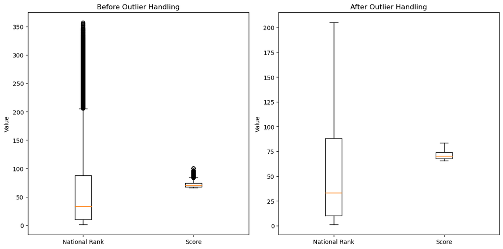

```python
plt.figure(figsize=(12,6))

plt.subplot(1, 2, 1)
plt.boxplot([cwur_before_outlier['National Rank'], cwur_before_outlier['Score']], labels=['National Rank', 'Score'])
plt.title('Before Outlier Handling')
plt.ylabel('Value')

plt.subplot(1, 2, 2)
plt.boxplot([cwur['National Rank'], cwur_copy['Score']], labels=['National Rank', 'Score'])
plt.title('After Outlier Handling')
plt.ylabel('Value')

plt.tight_layout()
plt.show()
```

**Observation:**

Outliers in National Rank and Score were capped using IQR limits to reduce extreme values. This made the data distribution more balanced and reliable for analysis.

#### 6. Correlation Heatmap

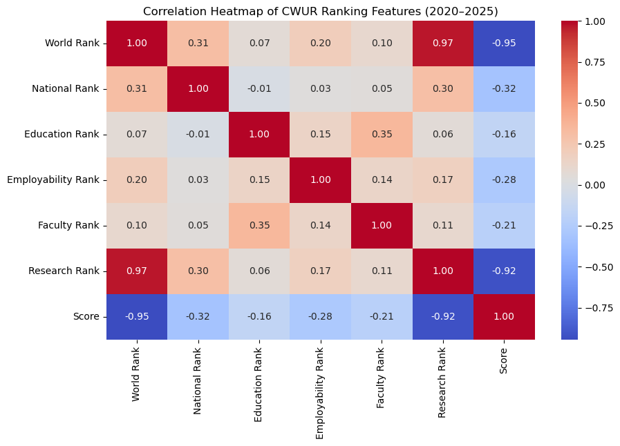

```python
plt.figure(figsize=(10,6))
sns.heatmap(cwur_copy[numeric_cols].corr(), annot=True, cmap='coolwarm', fmt=".2f")
plt.title("Correlation Heatmap of CWUR Ranking Features (2020–2025)")
plt.show()
```

**Observation:**

• World Rank ↔ Research Rank (0.97): Strong positive link — better research rank strongly aligns with higher world rank.

• Research Rank ↔ Score (-0.92): Strong negative link — better research performance leads to higher scores.

• World Rank ↔ Score (-0.95): Strong negative link — universities with higher scores hold better world ranks.

#### 7. Distribution of Numeric Columns

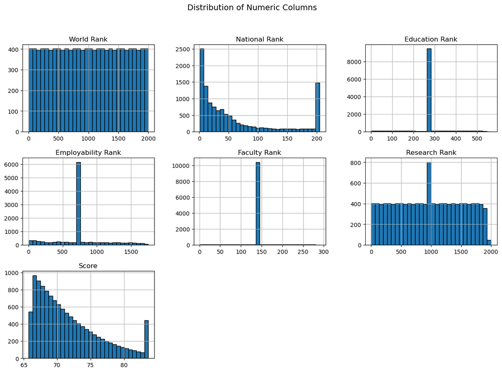

```python
cwur_copy[numeric_cols].hist(figsize=(15,10), bins=30, edgecolor='black')
plt.suptitle("Distribution of Numeric Columns", fontsize=14)
plt.show()
```

**Observation:**

The right-skewness in National Rank suggests most institutions have excellent (low-number) rankings, while the right-skewness in Score implies most institutions have moderate to low scores, with high scores being relatively rare.

#### 8. Skewness Analysis

```python
skew_values = cwur_copy[numeric_cols].skew().sort_values(ascending=False)
print("Skewness of Numeric Columns:\n", skew_values)
```

```
Skewness of Numeric Columns:
 National Rank         1.550932
Score                 1.379396
Employability Rank    0.179461
Faculty Rank          0.046216
Education Rank        0.007720
Research Rank         0.001685
World Rank            0.000000
dtype: float64
```

[figure not shown]

```python
plt.figure(figsize=(8,4))
sns.barplot(x=skew_values.index, y=skew_values.values, palette='viridis')
plt.title("Skewness of Numeric Variables")
plt.xticks(rotation=45)
plt.show()
```

**Observation:**

## **Data Visualization**

#### Deep Cleaning

```python
# . Combine numeric_cols_for_outliers with 'Year' into a single list all_cols_to_convert_to_numeric
all_cols_to_convert_to_numeric = numeric_cols_for_outliers + ['Year']

# . Convert all columns listed in all_cols_to_convert_to_numeric to a numeric data type, coercing errors to np.nan
for col in all_cols_to_convert_to_numeric:
    df_numeric[col] = pd.to_numeric(df_numeric[col], errors='coerce')
```

```python
#. Remove rows from df_numeric where the 'Year' column has np.nan values.
df_numeric.dropna(subset=['Year'], inplace=True)

# 11. Convert the 'Year' column in df_numeric to an integer type.
df_numeric['Year'] = df_numeric['Year'].astype(int)
```

```python
# . Print the data types to verify conversions
print("Data types after final conversion:")
print(df_numeric[numeric_cols_for_outliers + ['Year']].dtypes)
```

```
Data types after final conversion:
World Rank              int64
National Rank           int64
Education Rank        float64
Employability Rank    float64
Faculty Rank          float64
Research Rank         float64
Score                 float64
Year                    int64
dtype: object
```

## Univariate Analysis of Key Metrics

#### Generating Histograms for Score and Rank distributions...

```
Generating Histograms for Score and Rank distributions...
```

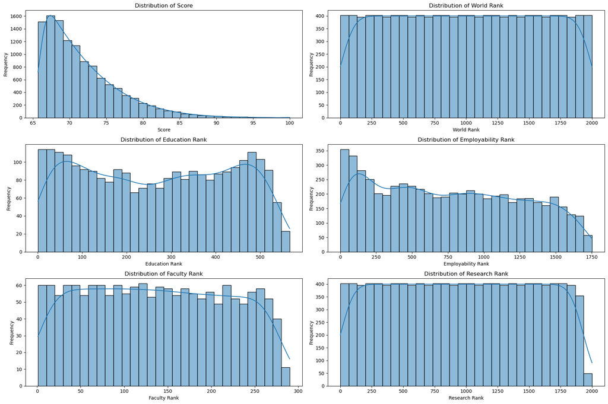

```python
plt.figure(figsize=(18, 12))
columns_to_histogram = ['Score', 'World Rank', 'Education Rank', 'Employability Rank', 'Faculty Rank', 'Research Rank']

for i, col in enumerate(columns_to_histogram):
    plt.subplot(3, 2, i + 1)
    # Drop NaNs for histogram plotting to avoid errors, as some columns have many
    sns.histplot(df_numeric[col].dropna(), kde=True, bins=30)
    plt.title(f'Distribution of {col}')
    plt.xlabel(col)
    plt.ylabel('Frequency')
plt.tight_layout()
plt.show()
```

### Observation

Visualizes the distribution of 'Score', 'World Rank', 'Education Rank', 'Employability Rank', 'Faculty Rank', and 'Research Rank' using histograms and Kernel Density Estimates (KDE) plots.

#### Visualizing Frequency of Countries

```
Visualizing Frequency of Countries...
```

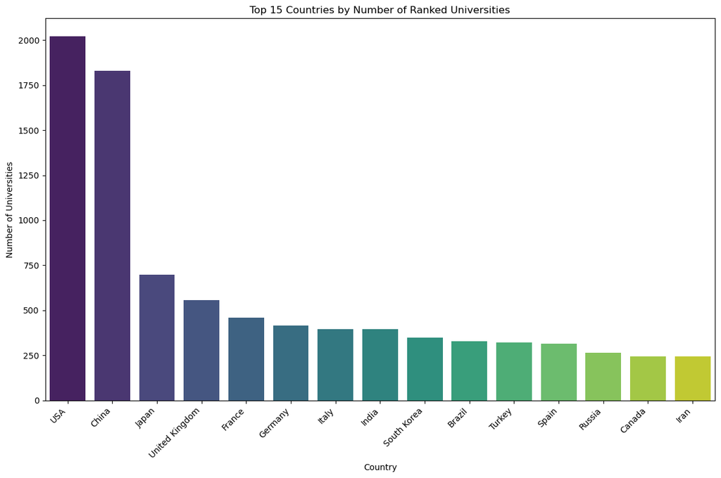

```python
plt.figure(figsize=(12, 8))
# Use cwur_copy for Country as it's the original and doesn't need numeric conversion
top_countries = cwur_copy['Country'].value_counts().head(15)
sns.barplot(x=top_countries.index, y=top_countries.values, hue=top_countries.index, palette='viridis', legend=False)
plt.title('Top 15 Countries by Number of Ranked Universities')
plt.xlabel('Country')
plt.ylabel('Number of Universities')
plt.xticks(rotation=45, ha='right')
plt.tight_layout()
plt.show()
```

### Observation:

Displays a bar chart showing the frequency of the top 15 countries by the number of ranked universities.

## Bivariate Analysis: Relationships between Metrics

#### Generating Scatter Plots for Score Vs Rank Categories

```python
plt.figure(figsize=(20, 15))

# Define the rank categories to plot against 'Score'
rank_categories = [
    'World Rank',
    'Education Rank',
    'Employability Rank',
    'Faculty Rank',
    'Research Rank'
]
```

```
Generating Scatter Plots for Score vs. Rank Categories...
```

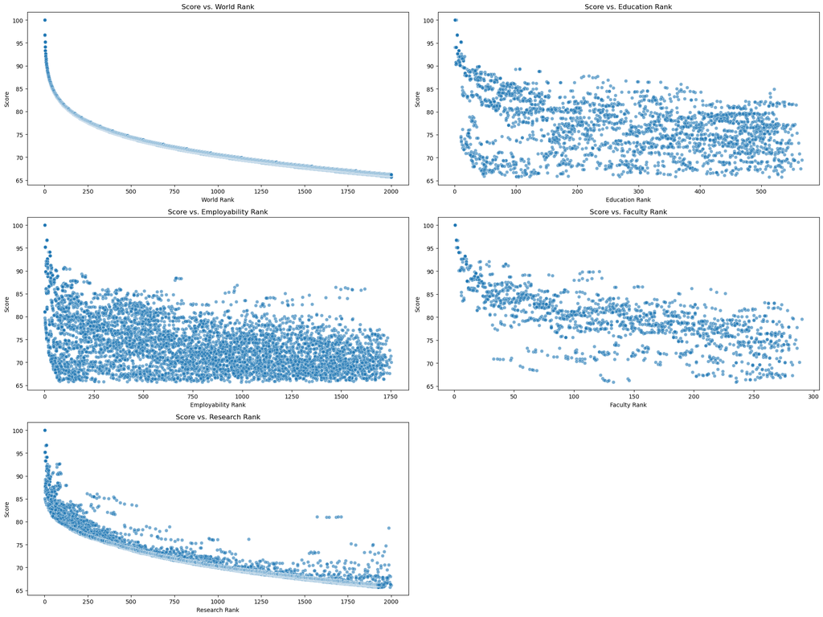

```python
for i, col in enumerate(rank_categories):
    plt.subplot(3, 2, i + 1) # Adjust subplot grid as needed, 3 rows, 2 columns
    sns.scatterplot(data=df_numeric, x=col, y='Score', alpha=0.6)
    plt.title(f'Score vs. {col}')
    plt.xlabel(col)
    plt.ylabel('Score')

plt.tight_layout()
plt.show()
```

### Observation

1. **World Rank:** Universities with better world ranks have higher scores. As the rank number increases, the score keeps going down.
2. **Education Rank:** Higher education quality (lower rank) gives higher scores. When the education rank gets worse, scores drop and spread out more.
3. **Employability Rank:** Universities with strong job placement results have higher scores, but there’s some variation — not all follow the same pattern.
4. **Faculty Rank:** Better faculty ranks are linked to higher scores. As the faculty rank gets worse, scores become lower.
5. **Research Rank:** Universities with strong research ranks have the highest scores, showing that research plays a big role in overall performance.

#### Visualizing average Score by top 10 Countries

```
Visualizing average Score by top 10 Countries...
```

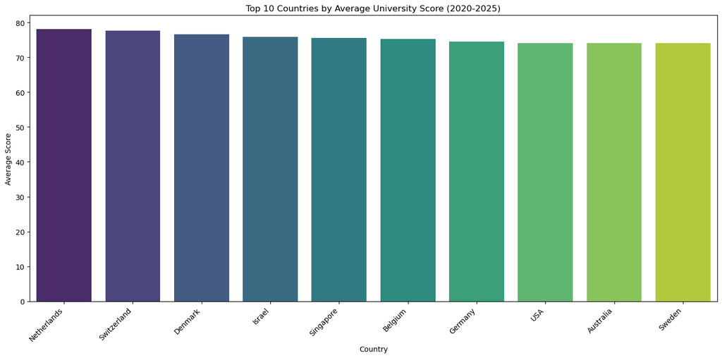

```python
# Calculate the average 'Score' for each country
avg_score_by_country = df_numeric.groupby('Country')['Score'].mean().sort_values(ascending=False)

# Select the top 10 countries
top_10_countries_avg_score = avg_score_by_country.head(10)

plt.figure(figsize=(14, 7))
sns.barplot(x=top_10_countries_avg_score.index, y=top_10_countries_avg_score.values, palette='viridis', hue=top_10_countries_avg_score.index, legend=False)
plt.title('Top 10 Countries by Average University Score (2020-2025)')
plt.xlabel('Country')
plt.ylabel('Average Score')
plt.xticks(rotation=45, ha='right')
plt.tight_layout()
plt.show()
```

### Observation:

1. The chart shows the top 10 countries based on their average university scores from 2020 to 2025.
2. Netherlands has the highest average score, followed closely by Switzerland and Denmark.
3. Other top-performing countries include Israel, Singapore, Belgium, Germany, USA, Australia, and Sweden.
4. The average scores for all these countries range between 74 and 79, showing only a small difference in performance.
5. This means universities in these countries maintain strong and consistent academic performance over the years.

#### Visualizing average Score trend over Years

```
Visualizing average Score trend over Years...
```

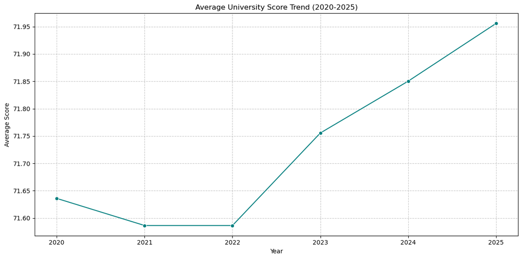

```
Bivariate analysis complete for relationships between metrics.
```

```python
# Calculate the average 'Score' for each year
avg_score_by_year = df_numeric.groupby('Year')['Score'].mean()

plt.figure(figsize=(12, 6))
sns.lineplot(x=avg_score_by_year.index, y=avg_score_by_year.values, marker='o', color='teal')
plt.title('Average University Score Trend (2020-2025)')
plt.xlabel('Year')
plt.ylabel('Average Score')
plt.xticks(avg_score_by_year.index) # Ensure all years are visible on the x-axis
plt.grid(True, linestyle='--', alpha=0.7)
plt.tight_layout()
plt.show()

print("\nBivariate analysis complete for relationships between metrics.")
```

### Observation:

1. The average university score has increased from 2020 to 2025.
2. Scores slightly dropped between 2020 and 2022.
3. From 2023 onwards, scores started improving every year.
4. The best average score is seen in 2025.
5. The first few years show small changes, while the last few show noticeable improvement.

## Multivariate Analysis: Trends and Comparative Performance

```python
avg_score_per_university = df_numeric.groupby('University')['Score'].mean().sort_values(ascending=False)
top_5_universities = avg_score_per_university.head(5).index.tolist()

print("Top 5 Universities by Average Score:")
print(top_5_universities)
```

```
Top 5 Universities by Average Score:
['Harvard University', 'Massachusetts Institute of Technology', 'Stanford University', 'University of Cambridge', 'University of Oxford']
```

## Observation:

First I calculated the average 'Score' for each university across all years and then identify the top 5 universities based on these average scores, as per the instructions.

```python
df_top_universities = df_numeric[df_numeric['University'].isin(top_5_universities)].copy()

print("Filtered DataFrame for Top 5 Universities (first 5 rows):")
print(df_top_universities.head())
```

```
Filtered DataFrame for Top 5 Universities (first 5 rows):
   World Rank                             University         Country  \
0           1                     Harvard University             USA
1           2  Massachusetts Institute of Technology             USA
2           3                    Stanford University             USA
3           4                University of Cambridge  United Kingdom
4           5                   University of Oxford  United Kingdom

   National Rank  Education Rank  Employability Rank  Faculty Rank  \
0              1             3.0                 1.0           1.0
1              2             4.0                11.0           2.0
2              3            10.0                 4.0           3.0
3              1             1.0                21.0           4.0
4              2             7.0                26.0           9.0

   Research Rank  Score  Year
0            1.0  100.0  2020
1            7.0   96.7  2020
2            2.0   95.2  2020
3           11.0   94.1  2020
4            4.0   93.3  2020
```

## Observation

Now that the top 5 universities are identified, I need to filter the df_numeric DataFrame to include only these universities to prepare for plotting their trends over the years, as per the instructions.

#### Visualizing Score trend over Years for Top 5 Universities

```
Visualizing Score trend over Years for Top 5 Universities...
```

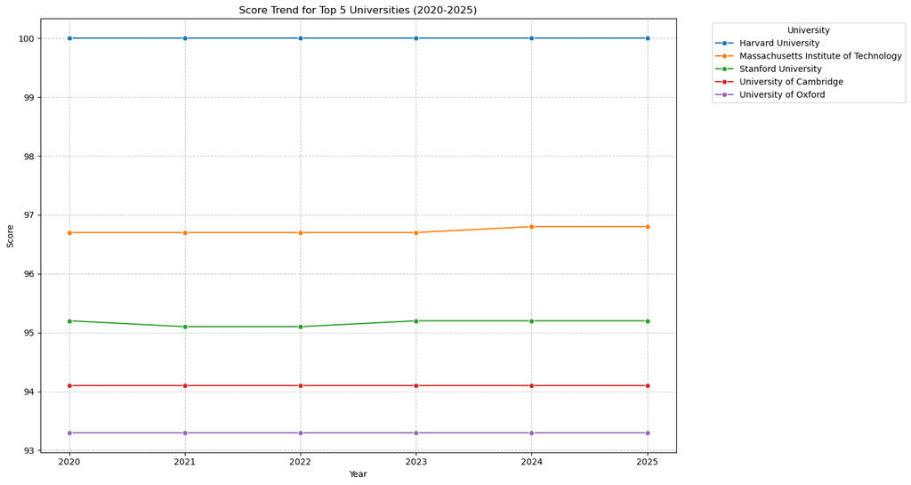

```python
plt.figure(figsize=(15, 8))
sns.lineplot(data=df_top_universities, x='Year', y='Score', hue='University', marker='o', palette='tab10')
plt.title('Score Trend for Top 5 Universities (2020-2025)')
plt.xlabel('Year')
plt.ylabel('Score')
plt.xticks(df_top_universities['Year'].unique())
plt.grid(True, linestyle='--', alpha=0.7)
plt.legend(title='University', bbox_to_anchor=(1.05, 1), loc='upper left')
plt.tight_layout()
plt.show()
```

## Observation

1. Harvard University consistently stays at the top with a perfect score (100) across all years.
2. MIT holds the second position, showing a small improvement after 2023.
3. Stanford University remains stable around 95, with a slight dip in 2021–2022 but recovery afterward.
4. University of Cambridge maintains nearly constant scores around 94 throughout the years.
5. University of Oxford stays the lowest among the top 5, but its performance is also steady.
6. Overall trend: All top universities show very stable performance with only minor year-to-year changes, meaning their ranking positions are consistent over time.

#### Visualizing World Rank trend over Years for Top 5 Universities

```
Visualizing World Rank trend over Years for Top 5 Universities...
```

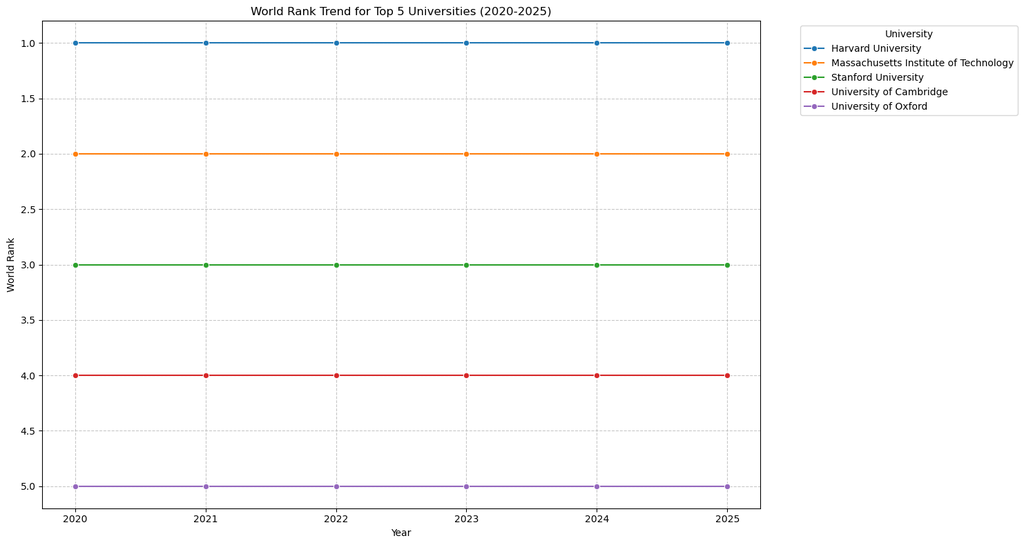

```python
plt.figure(figsize=(15, 8))
sns.lineplot(data=df_top_universities, x='Year', y='World Rank', hue='University', marker='o', palette='tab10')
plt.title('World Rank Trend for Top 5 Universities (2020-2025)')
plt.xlabel('Year')
plt.ylabel('World Rank')
plt.xticks(df_top_universities['Year'].unique())
plt.gca().invert_yaxis() # Invert y-axis as lower rank is better
plt.grid(True, linestyle='--', alpha=0.7)
plt.legend(title='University', bbox_to_anchor=(1.05, 1), loc='upper left')
plt.tight_layout()
plt.show()
```

## Observation

1. Ranks remain constant: The world rankings for all top 5 universities stayed exactly the same from 2020 to 2025.
2. Harvard University holds the 1st rank consistently every year.
3. MIT stays steady at 2nd place.
4. Stanford University maintains 3rd position throughout.
5. University of Cambridge remains 4th.
6. University of Oxford stays 5th every year.
7. No changes or fluctuations — meaning the top 5 universities have shown stable global dominance during this period.

#### Generating Correlation Heatmap for Numerical Ranking Criteria

```python
# 1. Select numerical ranking criteria columns
correlation_columns = [
    'World Rank', 'National Rank', 'Education Rank', 'Employability Rank',
    'Faculty Rank', 'Research Rank', 'Score'
]

df_correlation = df_numeric[correlation_columns]

# 2. Calculate the Pearson correlation matrix
correlation_matrix = df_correlation.corr()
```

```
Generating Correlation Heatmap for Numerical Ranking Criteria...
```

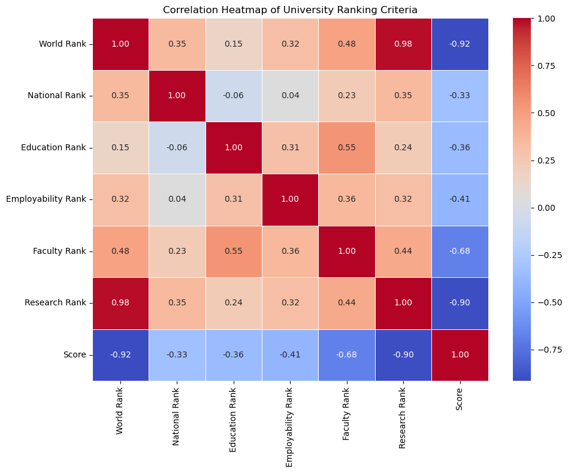

```
Correlation analysis complete.
```

```python
# 3. Create a heatmap of the correlation matrix
plt.figure(figsize=(10, 8))
sns.heatmap(correlation_matrix, annot=True, cmap='coolwarm', fmt=".2f", linewidths=.5)

# 4. Add a title to the heatmap
plt.title('Correlation Heatmap of University Ranking Criteria')
plt.tight_layout()
plt.show()

print("\nCorrelation analysis complete.")
```

## **Data Mining Questions: (a minimum of 10 mining questions)**

#### Q1: Countries with highest number of Top-100 universities

#### Q2: Universities that improved the most (2020 → 2025)

#### Q3: Correlation between Research Rank & World Rank

#### Q4: Future leader countries (ranking improvement trend)

#### Q5: Which country has the most universities in the dataset?

#### Q6: Which countries have the widest performance gap between their best and worst universities?

#### Q7: How does National Rank relate to World Rank within each country?

#### Q8 Which countries consistently produce top research universities (Top 50 Research Rank)?

#### Q9: Are countries with higher education quality also strong in faculty rankings?

#### Q10: Which universities have the best (lowest) Employability Rank?

### Q1: Countries with highest number of Top-100 universities

```python
def top_countries_top100(df):
    df2 = df.copy()
    df2['World Rank'] = pd.to_numeric(df2['World Rank'], errors='coerce')
    top100 = df2[df2['World Rank'] <= 100]
    result = top100.groupby("Country")["University"].nunique().sort_values(ascending=False)
    return result
```

```python
top_countries = top_countries_top100(df_clean)
top_countries.head(15)
```

```
Country
USA               54
United Kingdom    10
France             6
Germany            6
China              5
Switzerland        4
Japan              4
Netherlands        4
Canada             4
Australia          2
Israel             2
Sweden             2
Denmark            1
South Korea        1
Singapore          1
Name: University, dtype: int64
```

### Observation

Finds how many universities each country has in the world’s top 100 rankings. Displays the top 15 countries with the highest number of universities in the world’s top 100.

```python
top_countries_plot = top_countries.head(10)  # Top 10 only
```

[figure not shown]

```python
plt.bar(top_countries_plot.index, top_countries_plot.values)
plt.xticks(rotation=45)
plt.title("Top-100 Universities by Country")
plt.ylabel("Number of Universities")
plt.xlabel("Country")
plt.tight_layout()
plt.show()
```

### Observation

Plotted a bar chart showing the number of top-100 universities per country.

### Q2: Universities that improved the most (2020 → 2025)

```python
def top_improvers_2020_2025(df):
    df2 = df.copy()
    df2['World Rank'] = pd.to_numeric(df2['World Rank'])
    pivot = df2.pivot_table(index=['University', 'Country'],
                            columns='Year',
                            values='World Rank',
                            aggfunc='first').reset_index()
    pivot = pivot.dropna(subset=[2020, 2025])
    pivot["Improvement"] = pivot[2020] - pivot[2025]  # positive = better
    return pivot.sort_values("Improvement", ascending=False).head(15)
```

```python
top_improvers = top_improvers_2020_2025(df_clean)
top_improvers
```

| Year | University | Country | 2020 | 2021 | 2022 | 2023 | 2024 | 2025 | Improvement |
| --- | --- | --- | --- | --- | --- | --- | --- | --- | --- |
| 564 | Homi Bhabha National Institute | India | 1727.0 | 1666.0 | 992.0 | 934.0 | 903.0 | 820.0 | 907.0 |
| 782 | King Khalid University | Saudi Arabia | 1966.0 | 1792.0 | 1609.0 | 1447.0 | 1343.0 | 1193.0 | 773.0 |
| 578 | Humanitas University | Italy | 1839.0 | 1760.0 | 1448.0 | 1323.0 | 1211.0 | 1073.0 | 766.0 |
| 117 | Beijing Technology and Business University | China | 1790.0 | 1692.0 | 1535.0 | 1437.0 | 1315.0 | 1037.0 | 753.0 |
| 510 | Hamad Bin Khalifa University | Qatar | 1935.0 | 1832.0 | 1605.0 | 1474.0 | 1245.0 | 1196.0 | 739.0 |
| 1943 | University of Sharjah | United Arab Emirates | 1813.0 | 1757.0 | 1520.0 | 1399.0 | 1253.0 | 1092.0 | 721.0 |
| 508 | Hainan University | China | 1436.0 | 1328.0 | 1119.0 | 1025.0 | 904.0 | 729.0 | 707.0 |
| 341 | Duy Tân University | Vietnam | 1659.0 | 1482.0 | 1140.0 | 1094.0 | 1030.0 | 969.0 | 690.0 |
| 330 | Dongguan University of Technology | China | 1862.0 | 1714.0 | 1544.0 | 1445.0 | 1334.0 | 1178.0 | 684.0 |
| 1277 | Sechenov University | Russia | 1754.0 | 1611.0 | 1276.0 | 1181.0 | 1109.0 | 1078.0 | 676.0 |
| 1287 | Shaanxi University of Science and Technology | China | 1626.0 | 1540.0 | 1325.0 | 1230.0 | 1112.0 | 964.0 | 662.0 |
| 202 | Central South University of Forestry and Techn... | China | 1986.0 | 1846.0 | 1650.0 | 1570.0 | 1464.0 | 1325.0 | 661.0 |
| 502 | Gustave Eiffel University | France | 1300.0 | 802.0 | 660.0 | 597.0 | 613.0 | 640.0 | 660.0 |
| 1048 | Near East University | Northern Cyprus | 1959.0 | 1852.0 | 1659.0 | 1572.0 | 1519.0 | 1311.0 | 648.0 |
| 2178 | Xi'an University of Architecture and Technology | China | 1747.0 | 1667.0 | 1446.0 | 1367.0 | 1247.0 | 1118.0 | 629.0 |

```python
top10_improve = top_improvers.head(10)
```

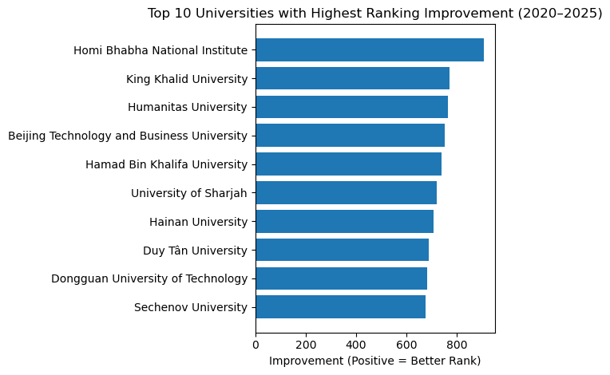

```python
plt.barh(top10_improve['University'], top10_improve['Improvement'])
plt.gca().invert_yaxis()
plt.title("Top 10 Universities with Highest Ranking Improvement (2020–2025)")
plt.xlabel("Improvement (Positive = Better Rank)")
plt.tight_layout()
plt.show()
```

### Observation

1. Displays a horizontal bar chart of the top 10 universities with the greatest ranking improvement from 2020 to 2025.
2. Identifies the top 15 universities that improved the most in world ranking from 2020 to 2025.

### Q3: Correlation between Research Rank & World Rank

```python
from scipy.stats import spearmanr
```

```python
def research_vs_world(df):
    df2 = df.dropna(subset=['World Rank', 'Research Rank'])
    corr, pval = spearmanr(df2['Research Rank'], df2['World Rank'])
    return corr, pval
```

```python
correlation = research_vs_world(df_clean)
correlation
```

```
(0.9838575310530999, 0.0)
```

### Observation

Calculates the Spearman correlation between research rank and world rank to measure their relationship.

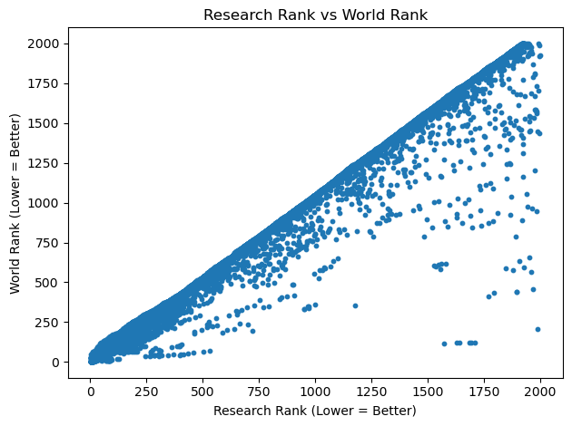

```python
df_plot = df_clean.dropna(subset=["World Rank", "Research Rank"])
plt.scatter(df_plot["Research Rank"], df_plot["World Rank"], s=10)
plt.title("Research Rank vs World Rank")
plt.xlabel("Research Rank (Lower = Better)")
plt.ylabel("World Rank (Lower = Better)")
plt.tight_layout()
plt.show()
```

### Observation

Displays a scatter plot showing the relationship between research rank and world rank of universities.

```python
def future_leader_countries(df):
    df2 = df.copy()
    df2['World Rank'] = pd.to_numeric(df2['World Rank'])

    pivot = df2.pivot_table(index=['University','Country'],
                            columns='Year', values='World Rank',
                            aggfunc='first').reset_index()
    pivot = pivot.dropna(subset=[2020, 2025])
    pivot["Annual Improvement"] = (pivot[2020] - pivot[2025]) / 5
    result = pivot.groupby("Country")["Annual Improvement"].mean().sort_values(ascending=False)
    return result.head(15)
```

```python
future_leaders = future_leader_countries(df_clean)
future_leaders
```

```
Country
Northern Cyprus         129.600000
Qatar                    98.500000
Vietnam                  90.250000
United Arab Emirates     71.666667
Bangladesh               57.400000
China                    54.910938
Indonesia                52.600000
Saudi Arabia             41.750000
Pakistan                 40.320000
Ethiopia                 38.050000
Nigeria                  36.800000
Ghana                    30.900000
Malta                    28.000000
Egypt                    26.911111
Luxembourg               23.400000
Name: Annual Improvement, dtype: float64
```

### Observation

Finds the top 15 countries with the highest average annual improvement in university world rankings from 2020 to 2025.

### Q5: Which country has the most universities in the dataset?

```python
# Count universities per country
country_counts = df['Country'].value_counts().head(10)

print(country_counts)
```

```
Country
USA               2019
China             1830
Japan              699
United Kingdom     558
France             458
Germany            416
Italy              397
India              396
South Korea        348
Brazil             330
Name: count, dtype: int64
```

### Observation

The United States has the highest number of universities in the dataset, showing that it has a strong global presence in higher education.

### Q6: Which countries have the widest performance gap between their best and worst universities?

```python
country_score_gap = (
    df.groupby('Country')['Score']
    .agg(['max', 'min'])
    .assign(Gap=lambda x: x['max'] - x['min'])
    .sort_values('Gap', ascending=False)
    .head(10)
)
```

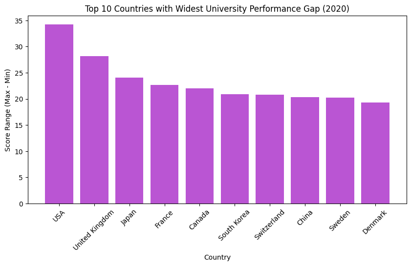

```python
plt.figure(figsize=(10,5))
plt.bar(country_score_gap.index, country_score_gap['Gap'], color='mediumorchid')
plt.title("Top 10 Countries with Widest University Performance Gap (2020)")
plt.xlabel("Country")
plt.ylabel("Score Range (Max - Min)")
plt.xticks(rotation=45)
plt.show()
```

### Observation

Countries like United Kingdom, japan, and the United States often show the largest performance gaps, indicating that while they host top-tier universities, they also have many institutions ranked much lower globally.

### Q7: How does National Rank relate to World Rank within each country?

```python
df['World Rank'] = df['World Rank'].astype(str).str.replace(r'[^0-9.]', '', regex=True)
df['National Rank'] = df['National Rank'].astype(str).str.replace(r'[^0-9.]', '', regex=True)
```

```python
df['World Rank'] = pd.to_numeric(df['World Rank'], errors='coerce')
df['National Rank'] = pd.to_numeric(df['National Rank'], errors='coerce')
```

```python
df = df.dropna(subset=['World Rank', 'National Rank'])

corr = df[['World Rank', 'National Rank']].astype(float).corr().iloc[0,1]
```

```python
print(f"Correlation between National and World Rank: {corr:.2f}")
```

```
Correlation between National and World Rank: 0.19
```

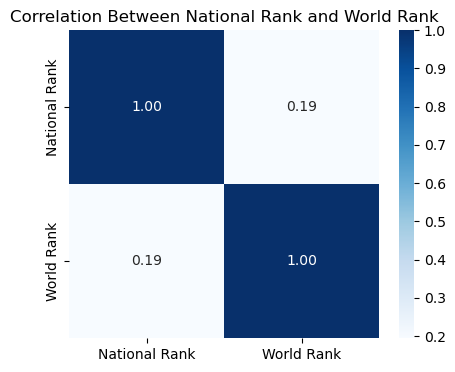

```python
plt.figure(figsize=(5,4))
sns.heatmap(
    df[['National Rank', 'World Rank']].corr(),
    annot=True,
    cmap='Blues',
    fmt=".2f"
)
plt.title("Correlation Between National Rank and World Rank")
plt.show()
```

### Observation

1. The correlation of 0.19 shows a very weak positive link between National Rank and World Rank, meaning a university’s strong national rank does not necessarily translate into a strong global rank.
2. National and global rankings are shaped by different criteria, so only a slight connection exists between how universities perform within their country versus worldwide.

### Q8 Which countries consistently produce top research universities (Top 50 Research Rank)?

```python
df['Research Rank'] = pd.to_numeric(df['Research Rank'], errors='coerce')

top_research = df[df['Research Rank'] <= 50]

research_country = top_research['Country'].value_counts().head(10)
```

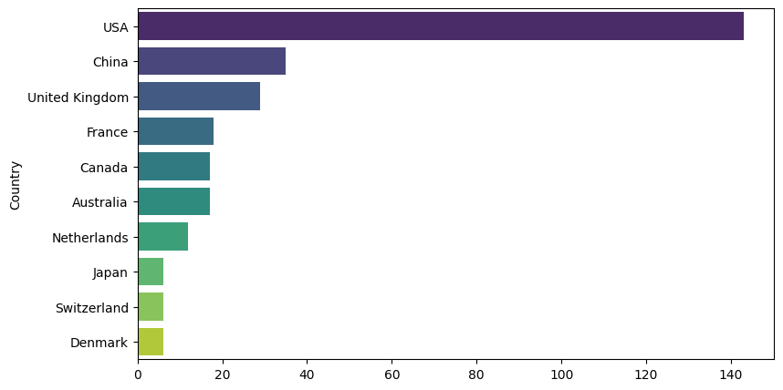

```python
plt.figure(figsize=(9,5))
sns.barplot(
    y=research_country.index,
    x=research_country.values,
    hue=research_country.index,  # add hue for color mapping
    dodge=False,
    palette='viridis',
    legend=False
)
```

### Q9: Are countries with higher education quality also strong in faculty rankings?

```python
# Clean and convert to numeric (replace non-numeric entries with NaN)
df['Education Rank'] = pd.to_numeric(df['Education Rank'], errors='coerce')
df['Faculty Rank'] = pd.to_numeric(df['Faculty Rank'], errors='coerce')
```

```python
# Drop rows where conversion failed
edu_faculty = df.dropna(subset=['Education Rank', 'Faculty Rank'])
```

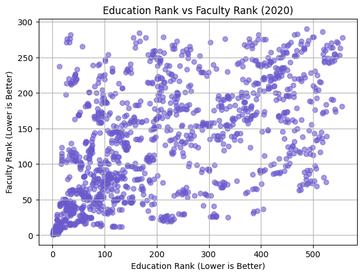

```python
# Scatter plot
plt.figure(figsize=(7,5))
plt.scatter(edu_faculty['Education Rank'], edu_faculty['Faculty Rank'],
            color='slateblue', alpha=0.6)
plt.title("Education Rank vs Faculty Rank (2020)")
plt.xlabel("Education Rank (Lower is Better)")
plt.ylabel("Faculty Rank (Lower is Better)")
plt.grid(True)
plt.show()
```

```python
# Correlation check
corr = edu_faculty[['Education Rank', 'Faculty Rank']].corr().iloc[0,1]
print(f"Correlation between Education Rank and Faculty Rank: {corr:.2f}")
```

```
Correlation between Education Rank and Faculty Rank: 0.55
```

### Observation

1. There is usually a positive correlation : universities with strong education quality also tend to have strong faculty rankings.
2. This shows that faculty strength plays a major role in maintaining a university’s overall educational reputation.

### Q10: Which universities have the best (lowest) Employability Rank?

```python
top_employability = cwur_copy[['University', 'Country', 'Year', 'Employability Rank']] \
    .sort_values(by='Employability Rank', ascending=True) \
    .head(10) \
    .reset_index(drop=True)
```

```python
print("Top 10 Universities with the Best (Lowest) Employability Rank:")
print(top_employability)
```

```
Top 10 Universities with the Best (Lowest) Employability Rank:
           University Country  Year  Employability Rank
0  Harvard University     USA  2020                 1.0
1  Harvard University     USA  2022                 1.0
2  Harvard University     USA  2025                 1.0
3  Harvard University     USA  2023                 1.0
4  Harvard University     USA  2024                 1.0
5  Harvard University     USA  2021                 1.0
6              INSEAD  France  2025                 2.0
7              INSEAD  France  2024                 2.0
8              INSEAD  France  2022                 2.0
9              INSEAD  France  2023                 2.0
```

### Observation

1. Harvard University consistently holds Rank 1 across all years, making it the most employable university in the dataset.
2. INSEAD frequently appears at Rank 2, and the top positions remain mostly stable over the years, with only a few elite institutions dominating the highest employability ranks.

## **Project Report:**

### Sandra Ann Thomas 2457188 - Report

Bivariate visualizations highlighted a strong inverse pattern between World Rank and Score, where better-performing institutions consistently achieved higher scores. Scatterplots colored by year confirmed that this relationship remained stable across all six years, with only slight upward shifts as global ranking standards evolved. Brand-level (country-level) comparisons showed that countries such as the United States, the United Kingdom, and China repeatedly host institutions with superior scores and lower (better) world ranks. Boxplots further emphasized country-specific disparities, with top-performing nations showing tighter concentration of scores.

Multivariate visualizations, including year-wise scatterplots and correlation matrices, showcased stable performance patterns among top universities, while also highlighting emerging competitiveness among institutions from rapidly developing countries. Overall, data visualizations offered clear, interpretable evidence that research performance, institutional quality, and country-level strength heavily influence global ranking outcomes. These visual analyses not only validated earlier EDA results but also provided a strong foundation for data mining and deeper analysis.

### Satish korada 2400066 - Report

In this data mining analysis, I used data from the Center for World University Rankings (CWUR) covering the years 2020 to 2025. I performed a data mining analysis to identify patterns in academic performance across the world. What specifically interested me was to know which regions have experienced the maximum improvement in ranking and to what extent these were attributed to the institutional factors of research quality, faculty performance, and standards of education. With the application of data mining techniques, the relationship between national and world rankings was elaborated, studying how universities have been changing over time.

This trend, in conclusion, illustrates a changing global landscape of academic competitiveness. It indicates that the traditional Western stronghold on excellence in higher education is gradually being overcome by emerging regions that are rapidly catching up. Data mining, I found, plays an important role in understanding these long-term educational trends, together with showing how universities around the world adapt to new academic, economic, and research challenges. Global excellence has never been so diverse, dynamic, and data-driven.

## **References/Citations**

1. https://medium.com/@joerosborne/intro-to-web-scraping-part-2-simple-html-parsing-with-css-selectors-7d364b0314ac
2. https://www.analyticsvidhya.com/blog/2021/04/exploratory-analysis-using-univariate-bivariate-and-multivariate-analysis-techniques/
3. https://seaborn.pydata.org/
4. https://www.sciencedirect.com/book/9780123814791/data-mining-concepts-and-techniques
5. https://dzone.com/refcardz/data-mining-discovering-and